# hr_logistic_regression_using_python_statsmodel_formula.api

Logistic Regression using Python (stasmodel.formula):

Kumar Rahul

### We will be using HR data in this exercise. Refer the Exhibit 1 to understand the feature list. Use the HR data and answer the below questions.

1. Load the dataset in Jupyter Notebook using pandas
2. Build a correlation matrix between all the numeric features in the dataset. Report the features, which are correlated at a cut-off of 0.70. What actions will you take on the features, which are highly correlated?
3. Build a new feature named LOB_Hike_Offered using LOB and percentage hike offered. Include this as a part of the data frame created in step 1. What assumption are you trying to test with such variables?
4. Create a new data frame with the numeric features and categorical features as dummy variable coded features. Which features will you include for model building and why?
5. Split the data into training set and test set. Use 80% of data for model training and 20% for model testing.
6. Build a model using Gender and Age as independent variable and Status as dependent variable.
   > - Are Gender and Age a significant feature in this model?
   > - What inferences can be drawn from this model?
7. Build a model with statsmodel.api to predict the probability of Not Joining. How do you interpret the model outcome? Report the model performance on the test set.
8. Build a model with statsmodel.formula.api to predict the probability of Not Joining and report the model performance on the test set. What difference do you observe in the model built here and the one built in step 7.
9. Build a model using sklearn package to predict the probability of Not Joining. What difference do you observe in this model compared to model built in step 7 and 8.
10. Fine-tune the cut-off value using cost of misclassification as a strategy. The cut-off should help classify maximum number of Not Joining cases correctly.
11. Fine-tune the cut-off value using youdens index as a strategy. The cut-off should help balance the classification of Joined and Not Joined cases.
12. Apply the cut-off values obtained in step 10 and step 11 on the test set. What inference can be deduced from it?
13. Build model using gradient descent to get an intuition about the inner working of optimization algorithms.
14. Build model using gradient descent with regularization to get an intution about the inner working of optimization algorithms.

**PS: Not all the questions are being answered as a part of the same notebook. You are encouraged to answer the questions if you find them missing.**

**Exhibit 1**

| Sl.No. | Name of Variable | Variable Description |
| --- | --- | --- |
| 1 | Candidate reference number | Unique number to identify the candidate |
| 2 | DOJ extended | Binary variable identifying whether candidate asked for date of joining extension (Yes/No) |
| 3 | Duration to accept the offer | Number of days taken by the candidate to accept the offer (continuous variable) |
| 4 | Notice period | Notice period to be served in the parting company before candidate can join this company (continuous variable) |
| 5 | Offered band | Band offered to the candidate based on experience and performance in interview rounds (categorical variable labelled C0/C1/C2/C3/C4/C5/C6) |
| 6 | Percentage hike (CTC) expected | Percentage hike expected by the candidate (continuous variable) |
| 7 | Percentage hike offered (CTC) | Percentage hike offered by the company (continuous variable) |
| 8 | Percent difference CTC | Percentage difference between offered and expected CTC (continuous variable) |
| 9 | Joining bonus | Binary variable indicating if joining bonus was given or not (Yes/No) |
| 10 | Gender | Gender of the candidate (Male/Female) |
| 11 | Candidate source | Source from which resume of the candidate was obtained (categorical variables with categories Employee referral/Agency/Direct) |
| 12 | REX (in years) | Relevant years of experience of the candidate for the position offered (continuous variable) |
| 13 | LOB | Line of business for which offer was rolled out (categorical variable) |
| 14 | DOB | Date of birth of the candidate |
| 15 | Joining location | Company location for which offer was rolled out for candidate to join (categorical variable) |
| 16 | Candidate relocation status | Binary variable indicating whether candidate has to relocate from one city to another city for joining (Yes/No) |
| 17 | HR status | Final joining status of candidate (Joined/Not-Joined) |

# Code starts here

To know the environment with the pyhton kernal

```python
import sys, os

sys.executable
```

Supress the warnings

```python
import warnings
warnings.filterwarnings("ignore")
```

We are going to use below mentioned libraries for **data import, processing and visulization**. As we progress, we will use other specific libraries for model building and evaluation.

```python
import pandas as pd
import numpy as np
import seaborn as sn # visualization library based on matplotlib
import matplotlib.pylab as plt

#the output of plotting commands is displayed inline within Jupyter notebook
%matplotlib inline
```

## Data Import and Manipulation

### 1. Importing a data set

*Give the correct path to the data*

modify the ast_note_interactivity kernel option to see the value of multiple statements at once.

```python
import os

os.getcwd()

#os.chdir()
```

```
'/Users/Rahul/Documents/Rahul Office/IIMB/Work @ IIMB/Training Material/Concepts/Python/ML_using_Python/Python_Code/Python_stats_logistic_regression/Code'
```

```python
from IPython.core.interactiveshell import InteractiveShell
InteractiveShell.ast_node_interactivity = "all"
```

```python
raw_df = pd.read_csv( "../HR_case/data/IMB533_HR_Data_No_Missing_Value.csv",
                        sep = ',', na_values = ['', ' '])

raw_df.columns = raw_df.columns.str.lower().str.replace(' ', '_')
raw_df.head()
```

|  | slno | candidate_ref | doj_extended | duration_to_accept_offer | notice_period | offered_band | pecent_hike_expected_in_ctc | percent_hike_offered_in_ctc | percent_difference_ctc | joining_bonus | candidate_relocate_actual | gender | candidate_source | rex_in_yrs | lob | location | age | status |
| --- | --- | --- | --- | --- | --- | --- | --- | --- | --- | --- | --- | --- | --- | --- | --- | --- | --- | --- |
| 0 | 1 | 2110407 | Yes | 14 | 30 | E2 | -20.79 | 13.16 | 42.86 | No | No | Female | Agency | 7 | ERS | Noida | 34 | Joined |
| 1 | 2 | 2112635 | No | 18 | 30 | E2 | 50.00 | 320.00 | 180.00 | No | No | Male | Employee Referral | 8 | INFRA | Chennai | 34 | Joined |
| 2 | 3 | 2112838 | No | 3 | 45 | E2 | 42.84 | 42.84 | 0.00 | No | No | Male | Agency | 4 | INFRA | Noida | 27 | Joined |
| 3 | 4 | 2115021 | No | 26 | 30 | E2 | 42.84 | 42.84 | 0.00 | No | No | Male | Employee Referral | 4 | INFRA | Noida | 34 | Joined |
| 4 | 5 | 2115125 | Yes | 1 | 120 | E2 | 42.59 | 42.59 | 0.00 | No | Yes | Male | Employee Referral | 6 | INFRA | Noida | 34 | Joined |

```python
#?pd.read_csv
```

Dropping SLNo and Candidate.Ref as these will not be used for any analysis or model building.

```python
#?raw_df.drop()
```

```python
if set(['slno','candidate_ref']).issubset(raw_df.columns):
    raw_df.drop(['slno','candidate_ref'],axis=1, inplace=True)

raw_df.head()
```

|  | doj_extended | duration_to_accept_offer | notice_period | offered_band | pecent_hike_expected_in_ctc | percent_hike_offered_in_ctc | percent_difference_ctc | joining_bonus | candidate_relocate_actual | gender | candidate_source | rex_in_yrs | lob | location | age | status |
| --- | --- | --- | --- | --- | --- | --- | --- | --- | --- | --- | --- | --- | --- | --- | --- | --- |
| 0 | Yes | 14 | 30 | E2 | -20.79 | 13.16 | 42.86 | No | No | Female | Agency | 7 | ERS | Noida | 34 | Joined |
| 1 | No | 18 | 30 | E2 | 50.00 | 320.00 | 180.00 | No | No | Male | Employee Referral | 8 | INFRA | Chennai | 34 | Joined |
| 2 | No | 3 | 45 | E2 | 42.84 | 42.84 | 0.00 | No | No | Male | Agency | 4 | INFRA | Noida | 27 | Joined |
| 3 | No | 26 | 30 | E2 | 42.84 | 42.84 | 0.00 | No | No | Male | Employee Referral | 4 | INFRA | Noida | 34 | Joined |
| 4 | Yes | 1 | 120 | E2 | 42.59 | 42.59 | 0.00 | No | Yes | Male | Employee Referral | 6 | INFRA | Noida | 34 | Joined |

### 2. Structure of the dataset

```python
raw_df.info()
```

```
<class 'pandas.core.frame.DataFrame'>
RangeIndex: 8995 entries, 0 to 8994
Data columns (total 16 columns):
 #   Column                       Non-Null Count  Dtype
---  ------                       --------------  -----
 0   doj_extended                 8995 non-null   object
 1   duration_to_accept_offer     8995 non-null   int64
 2   notice_period                8995 non-null   int64
 3   offered_band                 8995 non-null   object
 4   pecent_hike_expected_in_ctc  8995 non-null   float64
 5   percent_hike_offered_in_ctc  8995 non-null   float64
 6   percent_difference_ctc       8995 non-null   float64
 7   joining_bonus                8995 non-null   object
 8   candidate_relocate_actual    8995 non-null   object
 9   gender                       8995 non-null   object
 10  candidate_source             8995 non-null   object
 11  rex_in_yrs                   8995 non-null   int64
 12  lob                          8995 non-null   object
 13  location                     8995 non-null   object
 14  age                          8995 non-null   int64
 15  status                       8995 non-null   object
dtypes: float64(3), int64(4), object(9)
memory usage: 1.1+ MB
```

```python
raw_df.status.value_counts()
#raw_df.describe(include='all').transpose()
raw_df.describe().transpose()
```

```
Joined        7313
Not Joined    1682
Name: status, dtype: int64
```

|  | count | mean | std | min | 25% | 50% | 75% | max |
| --- | --- | --- | --- | --- | --- | --- | --- | --- |
| duration_to_accept_offer | 8995.0 | 21.434464 | 25.811616 | 0.00 | 3.00 | 10.0 | 33.00 | 224.00 |
| notice_period | 8995.0 | 39.291829 | 22.220239 | 0.00 | 30.00 | 30.0 | 60.00 | 120.00 |
| pecent_hike_expected_in_ctc | 8995.0 | 43.864804 | 29.788975 | -68.83 | 27.27 | 40.0 | 53.85 | 359.77 |
| percent_hike_offered_in_ctc | 8995.0 | 40.657356 | 36.064060 | -60.53 | 22.09 | 36.0 | 50.00 | 471.43 |
| percent_difference_ctc | 8995.0 | -1.573802 | 19.610729 | -67.27 | -8.33 | 0.0 | 0.00 | 300.00 |
| rex_in_yrs | 8995.0 | 4.239022 | 2.547571 | 0.00 | 3.00 | 4.0 | 6.00 | 24.00 |
| age | 8995.0 | 29.913174 | 4.097912 | 20.00 | 27.00 | 29.0 | 34.00 | 60.00 |

To get a help on the features of a object

```python
#?raw_df.status.value_counts()
```

### 2. Summarizing the dataset

Create a new data frame and store the raw data copy. This is being done to have a copy of the raw data intact for further manipulation if needed. The *dropna()* function is used for row wise deletion of missing value. The axis = 0 means row-wise, 1 means column wise.

```python
filter_df = raw_df.dropna(axis=0, how='any', thresh=None,
                             subset=None, inplace=False)

list(filter_df.columns )
```

```
['doj_extended',
 'duration_to_accept_offer',
 'notice_period',
 'offered_band',
 'pecent_hike_expected_in_ctc',
 'percent_hike_offered_in_ctc',
 'percent_difference_ctc',
 'joining_bonus',
 'candidate_relocate_actual',
 'gender',
 'candidate_source',
 'rex_in_yrs',
 'lob',
 'location',
 'age',
 'status']
```

```python
#?raw_df.dropna
```

We will first start by printing the unique labels in categorical features

```python
numerical_features = ['duration_to_accept_offer','notice_period','pecent_hike_expected_in_ctc',
                      'percent_hike_offered_in_ctc','percent_difference_ctc','rex_in_yrs','age']

categorical_features = ['doj_extended','offered_band','joining_bonus','candidate_relocate_actual',
                        'gender','candidate_source','lob','location','status']

for f in categorical_features:
    print("\nThe unique labels in {} is {}\n".format(f, filter_df[f].unique()))
    print("The values in {} is \n{}\n".format(f,  filter_df[f].value_counts()))
```

```
The unique labels in doj_extended is ['Yes' 'No']

The values in doj_extended is
No     4788
Yes    4207
Name: doj_extended, dtype: int64


The unique labels in offered_band is ['E2' 'E1' 'E3' 'E0']

The values in offered_band is
E1    5568
E2    2711
E3     505
E0     211
Name: offered_band, dtype: int64


The unique labels in joining_bonus is ['No' 'Yes']

The values in joining_bonus is
No     8578
Yes     417
Name: joining_bonus, dtype: int64


The unique labels in candidate_relocate_actual is ['No' 'Yes']

The values in candidate_relocate_actual is
No     7705
Yes    1290
Name: candidate_relocate_actual, dtype: int64


The unique labels in gender is ['Female' 'Male']

The values in gender is
Male      7444
Female    1551
Name: gender, dtype: int64
```

[output cut: 35 more lines]

```
Gurgaon       146
Kolkata       129
Pune           48
Others         13
Cochin          8
Ahmedabad       6
Name: location, dtype: int64


The unique labels in status is ['Joined' 'Not Joined']

The values in status is
Joined        7313
Not Joined    1682
Name: status, dtype: int64
```

Looking at the feature **line of business** it seems that *EAS, Healthcare and MMS* does not have enough observations and may be clubbed together

```python
filter_df['lob']=np.where(filter_df['lob'] =='EAS', 'Others', filter_df['lob'])
filter_df['lob']=np.where(filter_df['lob'] =='Healthcare', 'Others', filter_df['lob'])
filter_df['lob']=np.where(filter_df['lob'] =='MMS', 'Others', filter_df['lob'])
filter_df.lob.value_counts()
```

```
INFRA     2850
ERS       2426
BFSI      1396
ETS        691
CSMP       579
AXON       568
Others     485
Name: lob, dtype: int64
```

We will use **groupby** function of pandas to get deeper insights of the behaviour of people **Joining** or **Not Joining** the company. We will write a generic function to report the mean by any categorical variable.

```python
def group_by (categorical_features):
    return filter_df.groupby(categorical_features).mean()
```

```python
group_by("doj_extended")
group_by("status")
group_by("location")
```

| doj_extended | duration_to_accept_offer | notice_period | pecent_hike_expected_in_ctc | percent_hike_offered_in_ctc | percent_difference_ctc | rex_in_yrs | age |
| --- | --- | --- | --- | --- | --- | --- | --- |
| No | 13.171261 | 36.381579 | 43.907550 | 40.923223 | -1.443452 | 4.011696 | 29.699248 |
| Yes | 30.838840 | 42.603993 | 43.816154 | 40.354773 | -1.722154 | 4.497742 | 30.156644 |

| status | duration_to_accept_offer | notice_period | pecent_hike_expected_in_ctc | percent_hike_offered_in_ctc | percent_difference_ctc | rex_in_yrs | age |
| --- | --- | --- | --- | --- | --- | --- | --- |
| Joined | 20.624368 | 37.244633 | 43.860660 | 41.133205 | -1.262036 | 4.192944 | 30.004102 |
| Not Joined | 24.956599 | 48.192628 | 43.882818 | 38.588460 | -2.929298 | 4.439358 | 29.517836 |

| location | duration_to_accept_offer | notice_period | pecent_hike_expected_in_ctc | percent_hike_offered_in_ctc | percent_difference_ctc | rex_in_yrs | age |
| --- | --- | --- | --- | --- | --- | --- | --- |
| Ahmedabad | 0.500000 | 20.000000 | 33.445000 | 14.901667 | -14.191667 | 1.666667 | 27.500000 |
| Bangalore | 26.322870 | 40.156951 | 44.055359 | 40.284883 | -1.971148 | 4.455157 | 30.129148 |
| Chennai | 22.175556 | 39.100000 | 47.259362 | 43.916314 | -1.492286 | 4.176825 | 29.773333 |
| Cochin | 4.375000 | 30.000000 | 53.757500 | 25.423750 | -16.875000 | 2.250000 | 28.875000 |
| Gurgaon | 18.164384 | 40.171233 | 39.957466 | 34.970205 | -2.483356 | 3.835616 | 29.541096 |
| Hyderabad | 25.844575 | 42.580645 | 41.117889 | 39.962434 | -0.083021 | 5.214076 | 30.958944 |
| Kolkata | 25.062016 | 44.302326 | 42.501938 | 33.135116 | -5.988527 | 5.333333 | 31.465116 |
| Mumbai | 12.309645 | 30.685279 | 46.421066 | 42.124518 | -2.685228 | 4.096447 | 30.710660 |
| Noida | 16.857719 | 38.828383 | 40.262901 | 38.047811 | -1.072802 | 3.993766 | 29.635497 |
| Others | 10.076923 | 33.461538 | 45.862308 | 43.654615 | -1.286154 | 3.538462 | 30.769231 |
| Pune | 20.562500 | 39.375000 | 40.560625 | 33.723958 | -4.275000 | 5.000000 | 31.333333 |

### 3. Visualizing the Data

Plot can be done using the callable functions of

> 1. pandas library (http://pandas.pydata.org/pandas-docs/stable/visualization.html)
> 2. matplotlib library (https://matplotlib.org/) or
> 3. seaborn library (https://seaborn.pydata.org/) which is based on matplotlib and provides interface for drawing attractive statistical graphics.

#### 3a. Visualizing the Data using seaborn

Write a custom function to create bar plot to visulaize the average of numeric features w.r.t each categorical feature. Say, average number of days to accept the offer w.r.t status as joined vs. not joined.

```python
def bar_plot(xlabel,ylabel):
    sn.barplot(x = xlabel, y = ylabel, data= filter_df)
    plt.xlabel(xlabel, size = 14)
    plt.ylabel(ylabel, size = 14)
    #plt.grid(True)
    x1,x2,y1,y2 = plt.axis()
    plt.show()
```

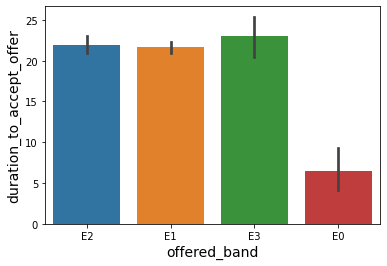

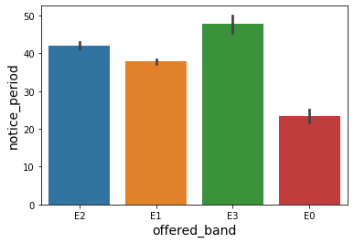

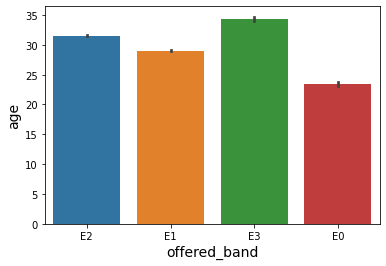

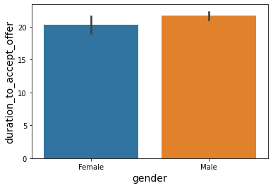

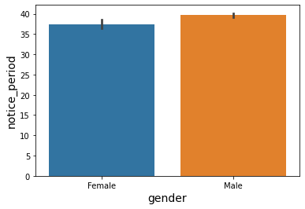

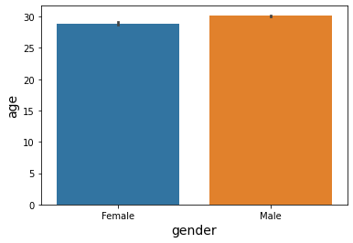

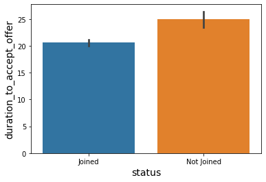

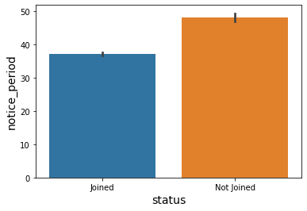

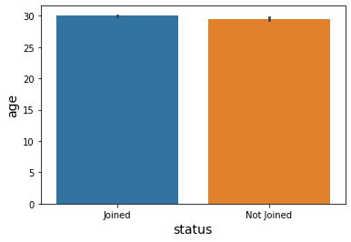

```python
numerical_features_set = ['duration_to_accept_offer','notice_period','age']
categorical_features_set = ['offered_band','gender','status']

for c in categorical_features_set:
    for n in numerical_features_set:
        bar_plot(c,n)
```

## Model: Without dummy variable coding (Using Statsmodel.formula.api)

Refer for details: https://www.statsmodels.org/dev/example_formulas.html and https://www.statsmodels.org/dev/examples/notebooks/generated/glm_formula.html

```python
import statsmodels.formula.api as smf
import statsmodels.api as sm
```

To print the name of all the models in any library

```python
#dir(smf)
```

### 3. Create train and test dataset

#### Train and test data split using Python

The train and test split can also be done using the **sklearn module**

```python
from sklearn.model_selection import train_test_split

train_df, test_df = train_test_split( filter_df, test_size = 0.2, random_state = 42)
```

We can pull the specific attribute needed to build the model is another data frame. This again is more of a hygine practice to not touch the **train** and **test** data set directly.

```python
lg_train_df = train_df.filter(['duration_to_accept_offer',
                               'notice_period',
                               'percent_difference_ctc',
                               'rex_in_yrs',
                               'age',
                               'doj_extended',
                               'offered_band',
#                               'pecent_hike_expected_in_ctc',
#                               'percent_hike_offered_in_ctc',
                               'joining_bonus',
#                               'candidate_relocate_actual',
                               'gender',
                               'candidate_source',
                               'lob',
                               'location',
                               'status'
                              ], axis = 1)

lg_test_df = test_df.filter(['duration_to_accept_offer',
                               'notice_period',
                               'percent_difference_ctc',
                               'rex_in_yrs',
                               'age',
                               'doj_extended',
                               'offered_band',
#                               'pecent_hike_expected_in_ctc',
#                               'percent_hike_offered_in_ctc',
                               'joining_bonus',
#                               'candidate_relocate_actual',
                               'gender',
                               'candidate_source',
                               'lob',
                               'location',
                               'status'
                              ], axis = 1)

lg_train_df.info()
```

```
<class 'pandas.core.frame.DataFrame'>
Int64Index: 7196 entries, 7842 to 7270
Data columns (total 13 columns):
 #   Column                    Non-Null Count  Dtype
---  ------                    --------------  -----
 0   duration_to_accept_offer  7196 non-null   int64
 1   notice_period             7196 non-null   int64
 2   percent_difference_ctc    7196 non-null   float64
 3   rex_in_yrs                7196 non-null   int64
 4   age                       7196 non-null   int64
 5   doj_extended              7196 non-null   object
 6   offered_band              7196 non-null   object
 7   joining_bonus             7196 non-null   object
 8   gender                    7196 non-null   object
 9   candidate_source          7196 non-null   object
 10  lob                       7196 non-null   object
 11  location                  7196 non-null   object
 12  status                    7196 non-null   object
dtypes: float64(1), int64(4), object(8)
memory usage: 787.1+ KB
```

Writing the formula with the required set of variables to be used in model building

```python
pass_formula = 'C(status) ~ \
            duration_to_accept_offer+ \
            notice_period + \
            percent_difference_ctc + \
            rex_in_yrs + \
            age + \
            C(doj_extended) + \
            C(offered_band) + \
            C(joining_bonus) + \
            C(gender) + \
            C(candidate_source) + \
            C(lob) + \
            C(location)'
```

```python
lg_reg_model = smf.glm(formula=pass_formula, data=lg_train_df, family=sm.families.Binomial()).fit()
lg_reg_model.summary()
```

Generalized Linear Model Regression Results

| Dep. Variable: | ['C(status)[Joined]', 'C(status)[Not Joined]'] | No. Observations: | 7196 |
| --- | --- | --- | --- |
| Model: | GLM | Df Residuals: | 7166 |
| Model Family: | Binomial | Df Model: | 29 |
| Link Function: | logit | Scale: | 1.0000 |
| Method: | IRLS | Log-Likelihood: | -3208.9 |
| Date: | Mon, 15 Mar 2021 | Deviance: | 6417.7 |
| Time: | 13:47:12 | Pearson chi2: | 7.26e+03 |
| No. Iterations: | 22 |  |  |
| Covariance Type: | nonrobust |  |  |

|  | coef | std err | z | P>\|z\| | [0.025 | 0.975] |
| --- | --- | --- | --- | --- | --- | --- |
| Intercept | -1.7847 | 1.225 | -1.457 | 0.145 | -4.185 | 0.616 |
| C(doj_extended)[T.Yes] | 0.1164 | 0.070 | 1.674 | 0.094 | -0.020 | 0.253 |
| C(offered_band)[T.E1] | 1.1534 | 0.218 | 5.281 | 0.000 | 0.725 | 1.581 |
| C(offered_band)[T.E2] | 0.9729 | 0.238 | 4.082 | 0.000 | 0.506 | 1.440 |
| C(offered_band)[T.E3] | 1.2232 | 0.305 | 4.012 | 0.000 | 0.626 | 1.821 |
| C(joining_bonus)[T.Yes] | 0.1017 | 0.152 | 0.669 | 0.504 | -0.197 | 0.400 |
| C(gender)[T.Male] | -0.0769 | 0.087 | -0.885 | 0.376 | -0.247 | 0.093 |
| C(candidate_source)[T.Direct] | 0.3204 | 0.073 | 4.407 | 0.000 | 0.178 | 0.463 |
| C(candidate_source)[T.Employee Referral] | 0.7187 | 0.108 | 6.660 | 0.000 | 0.507 | 0.930 |
| C(lob)[T.BFSI] | 0.1378 | 0.152 | 0.907 | 0.364 | -0.160 | 0.436 |
| C(lob)[T.CSMP] | 0.2776 | 0.176 | 1.577 | 0.115 | -0.067 | 0.623 |
| C(lob)[T.ERS] | 0.2273 | 0.143 | 1.590 | 0.112 | -0.053 | 0.507 |
| C(lob)[T.ETS] | 0.5430 | 0.171 | 3.170 | 0.002 | 0.207 | 0.879 |
| C(lob)[T.INFRA] | 0.7048 | 0.156 | 4.506 | 0.000 | 0.398 | 1.011 |
| C(lob)[T.Others] | 0.0453 | 0.176 | 0.257 | 0.797 | -0.300 | 0.391 |
| C(location)[T.Bangalore] | 1.2338 | 1.163 | 1.061 | 0.289 | -1.046 | 3.513 |
| C(location)[T.Chennai] | 1.2461 | 1.162 | 1.073 | 0.283 | -1.031 | 3.523 |
| C(location)[T.Cochin] | 22.6018 | 3.24e+04 | 0.001 | 0.999 | -6.35e+04 | 6.35e+04 |
| C(location)[T.Gurgaon] | 1.0596 | 1.183 | 0.896 | 0.370 | -1.259 | 3.378 |
| C(location)[T.Hyderabad] | 1.2898 | 1.171 | 1.101 | 0.271 | -1.006 | 3.585 |
| C(location)[T.Kolkata] | 1.3932 | 1.189 | 1.171 | 0.241 | -0.938 | 3.724 |
| C(location)[T.Mumbai] | 1.4642 | 1.187 | 1.234 | 0.217 | -0.862 | 3.790 |
| C(location)[T.Noida] | 1.6005 | 1.161 | 1.378 | 0.168 | -0.675 | 3.877 |
| C(location)[T.Others] | 22.6074 | 2.21e+04 | 0.001 | 0.999 | -4.33e+04 | 4.34e+04 |
| C(location)[T.Pune] | 1.5514 | 1.253 | 1.238 | 0.216 | -0.905 | 4.008 |
| duration_to_accept_offer | 0.0015 | 0.001 | 1.135 | 0.257 | -0.001 | 0.004 |
| notice_period | -0.0213 | 0.001 | -14.300 | 0.000 | -0.024 | -0.018 |
| percent_difference_ctc | 0.0029 | 0.002 | 1.597 | 0.110 | -0.001 | 0.007 |
| rex_in_yrs | -0.0552 | 0.022 | -2.512 | 0.012 | -0.098 | -0.012 |
| age | 0.0453 | 0.010 | 4.437 | 0.000 | 0.025 | 0.065 |

## Find the significant variables

```python
def get_significant_vars (modelobject):
    var_p_vals_df = pd.DataFrame(modelobject.pvalues)
    var_p_vals_df['vars'] = var_p_vals_df.index
    var_p_vals_df.columns = ['pvals', 'vars']
    return list(var_p_vals_df[var_p_vals_df.pvals <= 0.05]['vars'])
```

```python
significant_vars = get_significant_vars(lg_reg_model)
significant_vars
```

```
['C(offered_band)[T.E1]',
 'C(offered_band)[T.E2]',
 'C(offered_band)[T.E3]',
 'C(candidate_source)[T.Direct]',
 'C(candidate_source)[T.Employee Referral]',
 'C(lob)[T.ETS]',
 'C(lob)[T.INFRA]',
 'notice_period',
 'rex_in_yrs',
 'age']
```

## Model Evaluation

### 1. The prediction on train data.

Two ways to precit the outcome on the **train set**

> - Use **predict** function of the model object
> - Use **get_prediction** function of the model object

For the model with dummy variable coding explicetely done, we need to add the constant term to the test set. For the model with dummy variable coding carried out automatically, there is no need to add the constant term to the test set.

Here is the output with the model with no dummy variable coding

```python
predict_train_df = lg_reg_model.predict((lg_train_df))
predict_train_df.head()

predict_train_df = lg_reg_model.get_prediction(lg_train_df)
predict_train_df.predicted_mean[0:5]
```

```
7842    0.899629
5268    0.847675
6800    0.716612
7146    0.601952
5304    0.754362
dtype: float64
```

```
array([0.89962927, 0.84767467, 0.71661219, 0.60195179, 0.75436165])
```

### 2. The prediction on test data.

The prediction can be carried out by **defining functions** as well. Below is one such instance wherein a function is defined and is used for prediction

```python
def get_predictions ( test_class, model, test_data ):
    y_pred_df = pd.DataFrame( { 'actual': test_class,
                               'predicted_prob': model.get_prediction((test_data)).predicted_mean})
    return y_pred_df
```

```python
predict_test_df = pd.DataFrame(get_predictions(lg_test_df.status, lg_reg_model, lg_test_df))
predict_test_df.head()
```

|  | actual | predicted_prob |
| --- | --- | --- |
| 4622 | Joined | 0.951218 |
| 1530 | Joined | 0.887529 |
| 8706 | Joined | 0.908352 |
| 2233 | Joined | 0.763085 |
| 676 | Joined | 0.920820 |

```python
predict_test_df['predicted'] = predict_test_df.predicted_prob.map(lambda x: 'Joined' if x > 0.5 else 'Not Joined')
predict_test_df[0:10]
```

|  | actual | predicted_prob | predicted |
| --- | --- | --- | --- |
| 4622 | Joined | 0.951218 | Joined |
| 1530 | Joined | 0.887529 | Joined |
| 8706 | Joined | 0.908352 | Joined |
| 2233 | Joined | 0.763085 | Joined |
| 676 | Joined | 0.920820 | Joined |
| 6778 | Joined | 0.783545 | Joined |
| 2075 | Not Joined | 0.777212 | Joined |
| 6998 | Not Joined | 0.845174 | Joined |
| 8606 | Not Joined | 0.935241 | Joined |
| 7375 | Joined | 0.821034 | Joined |

### 3. Confusion Matrix

We will built classification matrix using the **metrics** method from **sklearn** package. We will also write a custom function to build a classification matrix and use it for reporting the performance measures.

#### 3a. Confusion Matrix using sklearn

```python
from sklearn import metrics
from sklearn.metrics import confusion_matrix
from sklearn.metrics import classification_report
```

```python
print("The model without dummy variable coding output: ")
confusion_matrix(lg_test_df.status, predict_test_df.predicted)
lg_reg_report = (classification_report(lg_test_df.status, predict_test_df.predicted))
print(lg_reg_report)
```

```
The model without dummy variable coding output:
```

```
array([[1448,   11],
       [ 331,    9]])
```

```
              precision    recall  f1-score   support

      Joined       0.81      0.99      0.89      1459
  Not Joined       0.45      0.03      0.05       340

    accuracy                           0.81      1799
   macro avg       0.63      0.51      0.47      1799
weighted avg       0.75      0.81      0.73      1799
```

#### 3b Confusion Matrix using generic function

```python
def draw_cm( actual, predicted ):
    plt.figure(figsize=(9,9))
    cm = metrics.confusion_matrix( actual, predicted )
    sn.heatmap(cm, annot=True,  fmt='.0f', xticklabels = ["Joined", "Not Joined"] ,
               yticklabels = ["Joined", "Not Joined"],cmap = 'Blues_r')
    plt.ylabel('Actual')
    plt.xlabel('Predicted')
    plt.title('Classification Matrix Plot', size = 15);
    plt.show()
```

The classification matrix plot as reported without dummy variable coding is:

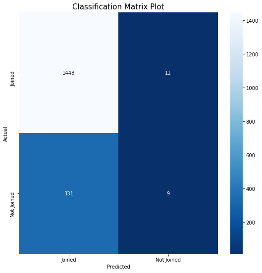

```python
draw_cm( predict_test_df.actual, predict_test_df.predicted )
```

### 4. Performance Measure on the test set

```python
def measure_performance (clasf_matrix):
    measure = pd.DataFrame({
                        'sensitivity': [round(clasf_matrix[0,0]/(clasf_matrix[0,0]+clasf_matrix[0,1]),2)],
                        'specificity': [round(clasf_matrix[1,1]/(clasf_matrix[1,0]+clasf_matrix[1,1]),2)],
                        'recall': [round(clasf_matrix[0,0]/(clasf_matrix[0,0]+clasf_matrix[0,1]),2)],
                        'precision': [round(clasf_matrix[0,0]/(clasf_matrix[0,0]+clasf_matrix[1,0]),2)],
                        'overall_acc': [round((clasf_matrix[0,0]+clasf_matrix[1,1])/
                                              (clasf_matrix[0,0]+clasf_matrix[0,1]+clasf_matrix[1,0]+clasf_matrix[1,1]),2)]
                       })
    return measure
```

```python
cm = metrics.confusion_matrix(predict_test_df.actual, predict_test_df.predicted)

lg_reg_metrics_df = pd.DataFrame(measure_performance(cm))
lg_reg_metrics_df

print( 'Total Accuracy sklearn: ',np.round( metrics.accuracy_score( lg_test_df.status, predict_test_df.predicted ), 2 ))
```

|  | sensitivity | specificity | recall | precision | overall_acc |
| --- | --- | --- | --- | --- | --- |
| 0 | 0.99 | 0.03 | 0.99 | 0.81 | 0.81 |

```
Total Accuracy sklearn:  0.81
```

### 5. The optimal cut-off

We are going to use model without dummy variable coding to select the optimal cut-off.

#### Select the optimal cut-off value, if:

> 1. Cost of Mis-classifying Not Joined as Joined is twice as costly as cost of micalssifying Joined as Not Joined
> 2. Both sensitivity and specificity are equally important

The best cut-off is the one which minimizes the misclassification cost (in case of *option 1*) or which maximizes the Youden's Index (in case of *Option 2*).

```python
lg_pred_prob_df = lg_reg_model.predict((lg_train_df))
n = len(lg_train_df)

costs =  pd.DataFrame.from_dict({'Joined': [0,1], 'Not Joined': [2,0]},
                    orient='index', columns=['Joined', 'Not Joined'])

print(costs)
costs.iloc[0][1] #to refer to specific value at a given position
```

```
            Joined  Not Joined
Joined           0           1
Not Joined       2           0
```

```
1
```

Defining loop function to loop through float values

```python
def frange(start, stop, step):
     s = start
     while s < stop:
         yield s
         s += step
```

```python
#creating empty vectors to store the results.
cutoff = []
P11 = [] #correct classification of positive as positive
P00 = [] #correct classification of negative as negative
P10 = [] #misclassification of positive class to negative class
P01 = [] #misclassification of negative class to positive class


for i in frange(0.00, 1, 0.05):
    predicted_y = lg_pred_prob_df.map(lambda x: 'Joined' if x > i else 'Not Joined')
    tbl = metrics.confusion_matrix(lg_train_df.status, predicted_y)
    if ( i <= 1):
        j = int(20*i)
        P01.append(tbl[1,0]/(tbl[1,0] + tbl[1,1]))
        P00.append(tbl[1,1]/(tbl[1,0] + tbl[1,1]))
        P10.append(tbl[0,1]/(tbl[0,0] + tbl[0,1]))
        P11.append(tbl[0,0]/(tbl[0,0] + tbl[0,1]))
        cutoff.append(i)

d = {'cutoff':cutoff,'P10':P10,'P01': P01,'P00': P00,'P11':P11}
df_cost_table = pd.DataFrame(d, columns=['cutoff','P00','P01','P10','P11'])
```

```python
df_cost_table
```

|  | cutoff | P00 | P01 | P10 | P11 |
| --- | --- | --- | --- | --- | --- |
| 0 | 0.00 | 0.000000 | 1.000000 | 0.000000 | 1.000000 |
| 1 | 0.05 | 0.000000 | 1.000000 | 0.000000 | 1.000000 |
| 2 | 0.10 | 0.000000 | 1.000000 | 0.000000 | 1.000000 |
| 3 | 0.15 | 0.000000 | 1.000000 | 0.000000 | 1.000000 |
| 4 | 0.20 | 0.000000 | 1.000000 | 0.000000 | 1.000000 |
| 5 | 0.25 | 0.000000 | 1.000000 | 0.000000 | 1.000000 |
| 6 | 0.30 | 0.000000 | 1.000000 | 0.000000 | 1.000000 |
| 7 | 0.35 | 0.000000 | 1.000000 | 0.000000 | 1.000000 |
| 8 | 0.40 | 0.004471 | 0.995529 | 0.001025 | 0.998975 |
| 9 | 0.45 | 0.017139 | 0.982861 | 0.003587 | 0.996413 |
| 10 | 0.50 | 0.046945 | 0.953055 | 0.008200 | 0.991800 |
| 11 | 0.55 | 0.079732 | 0.920268 | 0.016228 | 0.983772 |
| 12 | 0.60 | 0.115499 | 0.884501 | 0.030407 | 0.969593 |
| 13 | 0.65 | 0.183308 | 0.816692 | 0.052955 | 0.947045 |
| 14 | 0.70 | 0.277943 | 0.722057 | 0.097198 | 0.902802 |
| 15 | 0.75 | 0.413562 | 0.586438 | 0.173044 | 0.826956 |
| 16 | 0.80 | 0.602832 | 0.397168 | 0.329177 | 0.670823 |
| 17 | 0.85 | 0.789121 | 0.210879 | 0.531944 | 0.468056 |
| 18 | 0.90 | 0.917288 | 0.082712 | 0.754014 | 0.245986 |
| 19 | 0.95 | 0.989568 | 0.010432 | 0.955244 | 0.044756 |

The table summarizing the optimal cut-off value:

*write the cost.table into a csv file*

```python
df_cost_table['msclaf_cost'] = df_cost_table.P10*costs.iloc[0][1]+df_cost_table.P01*costs.iloc[1][0]
df_cost_table['youden_index'] = df_cost_table.P00+df_cost_table.P11 -1
df_cost_table

#write to csv
#df_cost_table.to_csv("optimal_Cutoff_caret.csv", sep=',')
#os.getcwd()
```

|  | cutoff | P00 | P01 | P10 | P11 | msclaf_cost | youden_index |
| --- | --- | --- | --- | --- | --- | --- | --- |
| 0 | 0.00 | 0.000000 | 1.000000 | 0.000000 | 1.000000 | 2.000000 | 0.000000 |
| 1 | 0.05 | 0.000000 | 1.000000 | 0.000000 | 1.000000 | 2.000000 | 0.000000 |
| 2 | 0.10 | 0.000000 | 1.000000 | 0.000000 | 1.000000 | 2.000000 | 0.000000 |
| 3 | 0.15 | 0.000000 | 1.000000 | 0.000000 | 1.000000 | 2.000000 | 0.000000 |
| 4 | 0.20 | 0.000000 | 1.000000 | 0.000000 | 1.000000 | 2.000000 | 0.000000 |
| 5 | 0.25 | 0.000000 | 1.000000 | 0.000000 | 1.000000 | 2.000000 | 0.000000 |
| 6 | 0.30 | 0.000000 | 1.000000 | 0.000000 | 1.000000 | 2.000000 | 0.000000 |
| 7 | 0.35 | 0.000000 | 1.000000 | 0.000000 | 1.000000 | 2.000000 | 0.000000 |
| 8 | 0.40 | 0.004471 | 0.995529 | 0.001025 | 0.998975 | 1.992083 | 0.003446 |
| 9 | 0.45 | 0.017139 | 0.982861 | 0.003587 | 0.996413 | 1.969310 | 0.013551 |
| 10 | 0.50 | 0.046945 | 0.953055 | 0.008200 | 0.991800 | 1.914310 | 0.038745 |
| 11 | 0.55 | 0.079732 | 0.920268 | 0.016228 | 0.983772 | 1.856765 | 0.063504 |
| 12 | 0.60 | 0.115499 | 0.884501 | 0.030407 | 0.969593 | 1.799408 | 0.085093 |
| 13 | 0.65 | 0.183308 | 0.816692 | 0.052955 | 0.947045 | 1.686338 | 0.130353 |
| 14 | 0.70 | 0.277943 | 0.722057 | 0.097198 | 0.902802 | 1.541312 | 0.180745 |
| 15 | 0.75 | 0.413562 | 0.586438 | 0.173044 | 0.826956 | 1.345920 | 0.240518 |
| 16 | 0.80 | 0.602832 | 0.397168 | 0.329177 | 0.670823 | 1.123513 | 0.273655 |
| 17 | 0.85 | 0.789121 | 0.210879 | 0.531944 | 0.468056 | 0.953703 | 0.257177 |
| 18 | 0.90 | 0.917288 | 0.082712 | 0.754014 | 0.245986 | 0.919439 | 0.163273 |
| 19 | 0.95 | 0.989568 | 0.010432 | 0.955244 | 0.044756 | 0.976109 | 0.034324 |

### 5. Confusion Matrix using Optimal Cut-off

The probability value along with the optimal cut-off can be used to build confusion matrix. We will use the **draw_cm** and **performance_measure** functions defined previously to report the performance of the model.

```python
predict_test_df['predicted'] = predict_test_df.predicted_prob.map(lambda x: 'Joined' if x > 0.8 else 'Not Joined')
predict_test_df[0:10]
```

|  | actual | predicted_prob | predicted |
| --- | --- | --- | --- |
| 4622 | Joined | 0.951218 | Joined |
| 1530 | Joined | 0.887529 | Joined |
| 8706 | Joined | 0.908352 | Joined |
| 2233 | Joined | 0.763085 | Not Joined |
| 676 | Joined | 0.920820 | Joined |
| 6778 | Joined | 0.783545 | Not Joined |
| 2075 | Not Joined | 0.777212 | Not Joined |
| 6998 | Not Joined | 0.845174 | Joined |
| 8606 | Not Joined | 0.935241 | Joined |
| 7375 | Joined | 0.821034 | Joined |

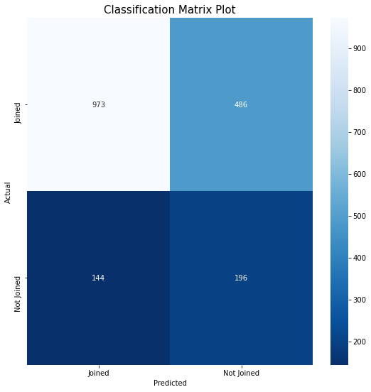

```python
draw_cm( predict_test_df.actual, predict_test_df.predicted )
```

```python
cm = metrics.confusion_matrix(predict_test_df.actual, predict_test_df.predicted)

pd.DataFrame(measure_performance(cm))
```

|  | sensitivity | specificity | recall | precision | overall_acc |
| --- | --- | --- | --- | --- | --- |
| 0 | 0.67 | 0.58 | 0.67 | 0.87 | 0.65 |

### 6. ROC Plot on the test data

```python
def draw_roc( actual, probs ):
    fpr, tpr, thresholds = metrics.roc_curve( actual, probs, drop_intermediate = False )
    auc_score = metrics.roc_auc_score( actual, probs )
    plt.figure(figsize=(10, 10))
    plt.plot( fpr, tpr, label='ROC curve (area = %0.2f)' % auc_score )
    plt.plot([0, 1], [0, 1], 'k--')
    plt.xlim([0.0, 1.0])
    plt.ylim([0.0, 1.05])
    plt.xlabel('False Positive Rate or [1 - True Negative Rate]')
    plt.ylabel('True Positive Rate')
    plt.title('Receiver operating characteristic example')
    plt.legend(loc="lower right")
    plt.show()

    return fpr, tpr, thresholds
```

Converting the labels to 0/1 code so that it can be passed to the sklearn identifies the positive and negative class.

```python
predict_test_df['predicted_code'] = predict_test_df.predicted.replace(('Joined', 'Not Joined'), (1, 0))
predict_test_df['actual_code'] = predict_test_df.actual.replace(('Joined', 'Not Joined'), (1, 0))
```

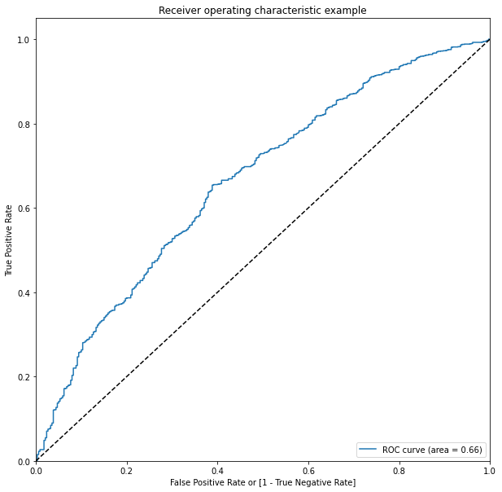

```python
fpr, tpr, thresholds = draw_roc(predict_test_df.actual_code, predict_test_df.predicted_prob )
```

```python
auc_score = metrics.roc_auc_score( predict_test_df.actual_code, predict_test_df.predicted_prob  )
round( float( auc_score ), 2 )
```

```
0.66
```